# dad_regression_using_python_statsmodel_formula

OLS Regression using Python (stasmodel.formula.api):

Kumar Rahul

### We will be using DAD hospital data in this exercise. Refer the Exhibit 1 to understand the feature list. Use the DAD Hospital data and answer the below questions.

**PS: Not all the questions are being answered as a part of the same notebook. You are encouraged to answer the questions if you find them missing.**

**Exhibit 1**

| Sl.No. | Variable | Description |
| --- | --- | --- |
| 1 | Age | Age of the patient in years |
| 2 | Body Weight | Weight of the patient in Kilograms |
| 3 | Body Height | Height of the patient in cm |
| 4 | HR Pulse | Pulse of patient at the time of admission |
| 5 | BP-High | High BP of patient (Systolic) |
| 6 | BP-Low | Low BP of patient (Diastolic) |
| 7 | RR | Respiratory rate of patient |
| 8 | HB | Hemoglobin count of patient |
| 9 | Urea | Urea levels of patient |
| 10 | Creatinine | Creatinine levels of patient |
| 11 | Marital Status | Marital status of the patient |
| 12 | Gender | Gender code for patient |
| 13 | Past Medical History Code | Code given to the past medical history of the Patient |
| 14 | Mode of Arrival | Way in which the patient arrived the hospital |
| 15 | State at the Time of Arrival | State in which the patient arrived |
| 16 | Type of Admission | Type of admission for the patient |
| 17 | Key Complaints Code | Codes given to the key complaints faced by the patient |
| 18 | Total Cost to Hospital | Actual cost incurred by the hospital |
| 19 | Total Length of Stay | Number of days patient stayed in the hospital |
| 20 | Length of Stay - ICU | Number of days patient stayed in the ICU |
| 21 | Length of Stay - Ward | Number of days patient stayed in the ward |
| 22 | Implant used (Y/N) | Any implant done on the patient |
| 23 | Cost of Implant | Total cost of all the implants done on the patient, if any |

# Code starts here

To know the environment with the pyhton kernal

```python
import sys, os

sys.executable
```

```
'/Users/Rahul/opt/anaconda3/bin/python'
```

Suppress the warnings

```python
import warnings

warnings.filterwarnings("ignore")
```

We are going to use below mentioned libraries for **data import, processing and visulization**. As we progress, we will use other specific libraries for model building and evaluation.

```python
import pandas as pd
import numpy as np
import seaborn as sn # visualization library based on matplotlib
import matplotlib.pylab as plt

#the output of plotting commands is displayed inline within Jupyter notebook
%matplotlib inline
```

## Data Import and Manipulation

### 1. Importing a data set

Modify the ast_note_interactivity kernel option to see the value of multiple statements at once.

```python
from IPython.core.interactiveshell import InteractiveShell
InteractiveShell.ast_node_interactivity = "all"
```

Change the display settings for columns

```python
pd.options.display.max_columns
pd.set_option('display.max_columns', None)
```

```
20
```

Pandas will start looking from where your current python file is located. Therefore you can move from your current directory to where your data is located with '..'

> - The single period . means current working directory
> - The double period .. means parent of the current working directory

```python
raw_df = pd.read_csv( "../DAD_hospital/data/DAD_Case_Data_Corrected.csv",
                        sep = ',', na_values = ['', ' '])

raw_df.columns = raw_df.columns.str.lower().str.replace('.', '_')
raw_df.head()
```

|  | sl no | age | gender | marital_status | key_complaints__code | body_weight | body_height | hr_pulse | bp__high | bp_low | rr | past_medical_history_code | hb | urea | creatinine | mode_of_arrival | state_at_the_time_of_arrival | type_of_admsn | total_cost_to_hospital | total_amount_billed_to_the_patient | concession | actual_receivable_amount | total_length_of_stay | length_of_stay___icu | length_of_stay__ward | implant_used | cost_of_implant |
| --- | --- | --- | --- | --- | --- | --- | --- | --- | --- | --- | --- | --- | --- | --- | --- | --- | --- | --- | --- | --- | --- | --- | --- | --- | --- | --- | --- |
| 0 | 1 | 58.0 | M | MARRIED | other- heart | 49 | 160 | 118 | 100 | 80 | 32 | None | 11 | 33 | 0.8 | AMBULANCE | ALERT | EMERGENCY | 660293.0 | 474901 | 0 | 474901 | 25 | 12 | 13 | Y | 38000 |
| 1 | 2 | 59.0 | M | MARRIED | CAD-DVD | 41 | 155 | 78 | 70 | 50 | 28 | None | 11 | 95 | 1.7 | AMBULANCE | ALERT | EMERGENCY | 809130.0 | 944819 | 96422 | 848397 | 41 | 20 | 21 | Y | 39690 |
| 2 | 3 | 82.0 | M | MARRIED | CAD-TVD | 47 | 164 | 100 | 110 | 80 | 20 | Diabetes2 | 12 | 15 | 0.8 | WALKED IN | ALERT | ELECTIVE | 362231.0 | 390000 | 30000 | 360000 | 18 | 9 | 9 | N | 0 |
| 3 | 4 | 46.0 | M | MARRIED | CAD-DVD | 80 | 173 | 122 | 110 | 80 | 24 | hypertension1 | 12 | 74 | 1.5 | AMBULANCE | ALERT | EMERGENCY | 629990.0 | 324910 | 0 | 324910 | 14 | 13 | 1 | Y | 89450 |
| 4 | 5 | 60.0 | M | MARRIED | CAD-DVD | 58 | 175 | 72 | 180 | 100 | 18 | Diabetes2 | 10 | 48 | 1.9 | AMBULANCE | ALERT | EMERGENCY | 444876.0 | 254673 | 10000 | 244673 | 24 | 12 | 12 | N | 0 |

```python
#?pd.read_csv
```

Dropping SL No as these will not be used for any analysis or model building.

```python
#?raw_df.drop()
```

```python
if set(['sl no']).issubset(raw_df.columns):
    raw_df.drop(['sl no'],axis=1, inplace=True)

raw_df.head()
```

|  | age | gender | marital_status | key_complaints__code | body_weight | body_height | hr_pulse | bp__high | bp_low | rr | past_medical_history_code | hb | urea | creatinine | mode_of_arrival | state_at_the_time_of_arrival | type_of_admsn | total_cost_to_hospital | total_amount_billed_to_the_patient | concession | actual_receivable_amount | total_length_of_stay | length_of_stay___icu | length_of_stay__ward | implant_used | cost_of_implant |
| --- | --- | --- | --- | --- | --- | --- | --- | --- | --- | --- | --- | --- | --- | --- | --- | --- | --- | --- | --- | --- | --- | --- | --- | --- | --- | --- |
| 0 | 58.0 | M | MARRIED | other- heart | 49 | 160 | 118 | 100 | 80 | 32 | None | 11 | 33 | 0.8 | AMBULANCE | ALERT | EMERGENCY | 660293.0 | 474901 | 0 | 474901 | 25 | 12 | 13 | Y | 38000 |
| 1 | 59.0 | M | MARRIED | CAD-DVD | 41 | 155 | 78 | 70 | 50 | 28 | None | 11 | 95 | 1.7 | AMBULANCE | ALERT | EMERGENCY | 809130.0 | 944819 | 96422 | 848397 | 41 | 20 | 21 | Y | 39690 |
| 2 | 82.0 | M | MARRIED | CAD-TVD | 47 | 164 | 100 | 110 | 80 | 20 | Diabetes2 | 12 | 15 | 0.8 | WALKED IN | ALERT | ELECTIVE | 362231.0 | 390000 | 30000 | 360000 | 18 | 9 | 9 | N | 0 |
| 3 | 46.0 | M | MARRIED | CAD-DVD | 80 | 173 | 122 | 110 | 80 | 24 | hypertension1 | 12 | 74 | 1.5 | AMBULANCE | ALERT | EMERGENCY | 629990.0 | 324910 | 0 | 324910 | 14 | 13 | 1 | Y | 89450 |
| 4 | 60.0 | M | MARRIED | CAD-DVD | 58 | 175 | 72 | 180 | 100 | 18 | Diabetes2 | 10 | 48 | 1.9 | AMBULANCE | ALERT | EMERGENCY | 444876.0 | 254673 | 10000 | 244673 | 24 | 12 | 12 | N | 0 |

### 2. Structure of the dataset

```python
raw_df.info()
```

```
<class 'pandas.core.frame.DataFrame'>
RangeIndex: 163 entries, 0 to 162
Data columns (total 26 columns):
 #   Column                              Non-Null Count  Dtype
---  ------                              --------------  -----
 0   age                                 163 non-null    float64
 1   gender                              163 non-null    object
 2   marital_status                      163 non-null    object
 3   key_complaints__code                163 non-null    object
 4   body_weight                         163 non-null    int64
 5   body_height                         163 non-null    int64
 6   hr_pulse                            163 non-null    int64
 7   bp__high                            163 non-null    int64
 8   bp_low                              163 non-null    int64
 9   rr                                  163 non-null    int64
```

[output cut: 18 more lines]

```python
raw_df.describe(include='all').transpose()
#raw_df.describe().transpose()
```

|  | count | unique | top | freq | mean | std | min | 25% | 50% | 75% | max |
| --- | --- | --- | --- | --- | --- | --- | --- | --- | --- | --- | --- |
| age | 163 | NaN | NaN | NaN | 31.6063 | 26.6156 | 0.83 | 6 | 21 | 58 | 88 |
| gender | 163 | 2 | M | 110 | NaN | NaN | NaN | NaN | NaN | NaN | NaN |
| marital_status | 163 | 2 | UNMARRIED | 85 | NaN | NaN | NaN | NaN | NaN | NaN | NaN |
| key_complaints__code | 163 | 13 | other- heart | 42 | NaN | NaN | NaN | NaN | NaN | NaN | NaN |
| body_weight | 163 | NaN | NaN | NaN | 39.5521 | 22.9404 | 3 | 16.5 | 43 | 59.5 | 85 |
| body_height | 163 | NaN | NaN | NaN | 133.607 | 38.1152 | 19 | 110.5 | 151 | 162 | 185 |
| hr_pulse | 163 | NaN | NaN | NaN | 90.9141 | 19.3998 | 58 | 76 | 90 | 102 | 140 |
| bp__high | 163 | NaN | NaN | NaN | 113.767 | 23.228 | 70 | 100 | 110 | 130 | 215 |
| bp_low | 163 | NaN | NaN | NaN | 71.5337 | 15.7195 | 40 | 60 | 70 | 80 | 140 |
| rr | 163 | NaN | NaN | NaN | 23.227 | 3.77173 | 12 | 22 | 24 | 24 | 42 |
| past_medical_history_code | 163 | 7 | None | 105 | NaN | NaN | NaN | NaN | NaN | NaN | NaN |
| hb | 163 | NaN | NaN | NaN | 13.2086 | 3.10009 | 8 | 11 | 13 | 14.5 | 26 |
| urea | 163 | NaN | NaN | NaN | 28.4724 | 17.9362 | 15 | 18 | 24 | 32 | 143 |
| creatinine | 163 | NaN | NaN | NaN | 0.718405 | 0.461912 | 0.1 | 0.3 | 0.6 | 1 | 2.5 |
| mode_of_arrival | 163 | 3 | WALKED IN | 138 | NaN | NaN | NaN | NaN | NaN | NaN | NaN |
| state_at_the_time_of_arrival | 163 | 1 | ALERT | 163 | NaN | NaN | NaN | NaN | NaN | NaN | NaN |
| type_of_admsn | 163 | 2 | ELECTIVE | 138 | NaN | NaN | NaN | NaN | NaN | NaN | NaN |
| total_cost_to_hospital | 163 | NaN | NaN | NaN | 213398 | 136952 | 46093 | 137288 | 169951 | 247792 | 887350 |
| total_amount_billed_to_the_patient | 163 | NaN | NaN | NaN | 191525 | 116874 | 43641 | 150000 | 150000 | 209675 | 944819 |
| concession | 163 | NaN | NaN | NaN | 16100.8 | 20383.7 | 0 | 0 | 2196 | 37500 | 123132 |
| actual_receivable_amount | 163 | NaN | NaN | NaN | 178482 | 123157 | 31000 | 112500 | 137000 | 203722 | 848397 |
| total_length_of_stay | 163 | NaN | NaN | NaN | 12.0061 | 5.46763 | 3 | 8 | 11 | 14 | 41 |
| length_of_stay___icu | 163 | NaN | NaN | NaN | 3.84049 | 3.85049 | 0 | 1 | 2 | 5 | 22 |
| length_of_stay__ward | 163 | NaN | NaN | NaN | 8.18405 | 3.80908 | 0 | 6 | 7 | 10 | 22 |
| implant_used | 163 | 2 | N | 126 | NaN | NaN | NaN | NaN | NaN | NaN | NaN |
| cost_of_implant | 163 | NaN | NaN | NaN | 10137.3 | 24193.8 | 0 | 0 | 0 | 0 | 196848 |

Get numeric features from the data and find the corelation amongst numeric features

```python
numerical_features = [x for x in raw_df.select_dtypes(include=[np.number])]
numerical_features
```

```
['age',
 'body_weight',
 'body_height',
 'hr_pulse',
 'bp__high',
 'bp_low',
 'rr',
 'hb',
 'urea',
 'creatinine',
 'total_cost_to_hospital',
 'total_amount_billed_to_the_patient',
 'concession',
 'actual_receivable_amount',
 'total_length_of_stay',
 'length_of_stay___icu',
 'length_of_stay__ward',
 'cost_of_implant']
```

```python
numerical_features_df = raw_df.select_dtypes(include=[np.number])
numerical_features_df.corr()
```

|  | age | body_weight | body_height | hr_pulse | bp__high | bp_low | rr | hb | urea | creatinine | total_cost_to_hospital | total_amount_billed_to_the_patient | concession | actual_receivable_amount | total_length_of_stay | length_of_stay___icu | length_of_stay__ward | cost_of_implant |
| --- | --- | --- | --- | --- | --- | --- | --- | --- | --- | --- | --- | --- | --- | --- | --- | --- | --- | --- |
| age | 1.000000 | 0.843398 | 0.722565 | -0.451244 | 0.586568 | 0.465456 | -0.234808 | -0.218499 | 0.285690 | 0.708491 | 0.499186 | 0.499330 | -0.387066 | 0.549550 | 0.345171 | 0.494728 | -0.013214 | 0.148869 |
| body_weight | 0.843398 | 1.000000 | 0.846622 | -0.534041 | 0.593387 | 0.482086 | -0.307728 | -0.147971 | 0.222444 | 0.714043 | 0.449536 | 0.446368 | -0.429783 | 0.524614 | 0.178323 | 0.382562 | -0.133412 | 0.277878 |
| body_height | 0.722565 | 0.846622 | 1.000000 | -0.484088 | 0.511962 | 0.434896 | -0.295007 | -0.062932 | 0.225537 | 0.620786 | 0.390078 | 0.418448 | -0.309462 | 0.473479 | 0.114701 | 0.277546 | -0.116847 | 0.299271 |
| hr_pulse | -0.451244 | -0.534041 | -0.484088 | 1.000000 | -0.291634 | -0.207449 | 0.373234 | 0.099655 | -0.024116 | -0.334538 | -0.060195 | -0.057116 | 0.199744 | -0.103888 | 0.009433 | -0.080921 | 0.097868 | -0.044194 |
| bp__high | 0.586568 | 0.593387 | 0.511962 | -0.291634 | 1.000000 | 0.772989 | -0.083097 | -0.083930 | 0.096395 | 0.443001 | 0.217561 | 0.226300 | -0.294828 | 0.281007 | 0.121619 | 0.189863 | -0.025814 | -0.016220 |
| bp_low | 0.465456 | 0.482086 | 0.434896 | -0.207449 | 0.772989 | 1.000000 | -0.015695 | 0.034689 | 0.043500 | 0.319224 | 0.211650 | 0.199455 | -0.265444 | 0.262555 | 0.107979 | 0.141541 | 0.007834 | 0.061073 |
| rr | -0.234808 | -0.307728 | -0.295007 | 0.373234 | -0.083097 | -0.015695 | 1.000000 | 0.035520 | 0.063190 | -0.158310 | 0.045726 | 0.069940 | 0.195671 | 0.039106 | 0.170249 | 0.051388 | 0.195577 | 0.051949 |
| hb | -0.218499 | -0.147971 | -0.062932 | 0.099655 | -0.083930 | 0.034689 | 0.035520 | 1.000000 | -0.096701 | -0.227718 | -0.094229 | -0.101410 | 0.173086 | -0.118508 | -0.024840 | -0.131131 | 0.104414 | -0.070642 |
| urea | 0.285690 | 0.222444 | 0.225537 | -0.024116 | 0.096395 | 0.043500 | 0.063190 | -0.096701 | 1.000000 | 0.639180 | 0.280680 | 0.283243 | -0.073098 | 0.283019 | 0.236011 | 0.254400 | 0.083921 | 0.247417 |
| creatinine | 0.708491 | 0.714043 | 0.620786 | -0.334538 | 0.443001 | 0.319224 | -0.158310 | -0.227718 | 0.639180 | 1.000000 | 0.516058 | 0.499464 | -0.274000 | 0.523746 | 0.354600 | 0.486857 | 0.016657 | 0.198562 |
| total_cost_to_hospital | 0.499186 | 0.449536 | 0.390078 | -0.060195 | 0.217561 | 0.211650 | 0.045726 | -0.094229 | 0.280680 | 0.516058 | 1.000000 | 0.799715 | -0.082807 | 0.770121 | 0.697723 | 0.847453 | 0.144412 | 0.479863 |
| total_amount_billed_to_the_patient | 0.499330 | 0.446368 | 0.418448 | -0.057116 | 0.226300 | 0.199455 | 0.069940 | -0.101410 | 0.283243 | 0.499464 | 0.799715 | 1.000000 | 0.071289 | 0.930575 | 0.632748 | 0.640583 | 0.256789 | 0.331455 |
| concession | -0.387066 | -0.429783 | -0.309462 | 0.199744 | -0.294828 | -0.265444 | 0.195671 | 0.173086 | -0.073098 | -0.274000 | -0.082807 | 0.071289 | 1.000000 | -0.117587 | 0.010689 | -0.087869 | 0.103308 | -0.117630 |
| actual_receivable_amount | 0.549550 | 0.524614 | 0.473479 | -0.103888 | 0.281007 | 0.262555 | 0.039106 | -0.118508 | 0.283019 | 0.523746 | 0.770121 | 0.930575 | -0.117587 | 1.000000 | 0.612376 | 0.649429 | 0.218826 | 0.323549 |
| total_length_of_stay | 0.345171 | 0.178323 | 0.114701 | 0.009433 | 0.121619 | 0.107979 | 0.170249 | -0.024840 | 0.236011 | 0.354600 | 0.697723 | 0.632748 | 0.010689 | 0.612376 | 1.000000 | 0.721035 | 0.707134 | 0.112062 |
| length_of_stay___icu | 0.494728 | 0.382562 | 0.277546 | -0.080921 | 0.189863 | 0.141541 | 0.051388 | -0.131131 | 0.254400 | 0.486857 | 0.847453 | 0.640583 | -0.087869 | 0.649429 | 0.721035 | 1.000000 | 0.021795 | 0.182783 |
| length_of_stay__ward | -0.013214 | -0.133412 | -0.116847 | 0.097868 | -0.025814 | 0.007834 | 0.195577 | 0.104414 | 0.083921 | 0.016657 | 0.144412 | 0.256789 | 0.103308 | 0.218826 | 0.707134 | 0.021795 | 1.000000 | -0.022505 |
| cost_of_implant | 0.148869 | 0.277878 | 0.299271 | -0.044194 | -0.016220 | 0.061073 | 0.051949 | -0.070642 | 0.247417 | 0.198562 | 0.479863 | 0.331455 | -0.117630 | 0.323549 | 0.112062 | 0.182783 | -0.022505 | 1.000000 |

```python
categorical_features = [x for x in raw_df.select_dtypes(include=[np.object])]
categorical_features
```

```
['gender',
 'marital_status',
 'key_complaints__code',
 'past_medical_history_code',
 'mode_of_arrival',
 'state_at_the_time_of_arrival',
 'type_of_admsn',
 'implant_used']
```

### 2. Summarizing the dataset

Create a new data frame and store the raw data copy. This is being done to have a copy of the raw data intact for further manipulation if needed. The *dropna()* function is used for row wise deletion of missing value. The axis = 0 means row-wise, 1 means column wise.

```python
filter_df = raw_df.dropna(axis=0, how='any', thresh=None,
                             subset=None, inplace=False)

list(filter_df.columns )
```

```
['age',
 'gender',
 'marital_status',
 'key_complaints__code',
 'body_weight',
 'body_height',
 'hr_pulse',
 'bp__high',
 'bp_low',
 'rr',
 'past_medical_history_code',
 'hb',
 'urea',
 'creatinine',
 'mode_of_arrival',
 'state_at_the_time_of_arrival',
 'type_of_admsn',
 'total_cost_to_hospital',
 'total_amount_billed_to_the_patient',
 'concession',
 'actual_receivable_amount',
 'total_length_of_stay',
 'length_of_stay___icu',
 'length_of_stay__ward',
 'implant_used',
 'cost_of_implant']
```

```python
filter_df.info()
```

```
<class 'pandas.core.frame.DataFrame'>
Int64Index: 163 entries, 0 to 162
Data columns (total 26 columns):
 #   Column                              Non-Null Count  Dtype
---  ------                              --------------  -----
 0   age                                 163 non-null    float64
 1   gender                              163 non-null    object
 2   marital_status                      163 non-null    object
 3   key_complaints__code                163 non-null    object
 4   body_weight                         163 non-null    int64
 5   body_height                         163 non-null    int64
 6   hr_pulse                            163 non-null    int64
 7   bp__high                            163 non-null    int64
 8   bp_low                              163 non-null    int64
 9   rr                                  163 non-null    int64
```

[output cut: 18 more lines]

We will first start by printing the unique labels in categorical features

```python
for f in categorical_features:
    print("\nThe unique labels in {} is {}\n".format(f, filter_df[f].unique()))
    print("The values in {} is \n{}\n".format(f,  filter_df[f].value_counts()))
```

```
The unique labels in gender is ['M' 'F']

The values in gender is
M    110
F     53
Name: gender, dtype: int64


The unique labels in marital_status is ['MARRIED' 'UNMARRIED']

The values in marital_status is
UNMARRIED    85
MARRIED      78
Name: marital_status, dtype: int64


The unique labels in key_complaints__code is ['other- heart' 'CAD-DVD' 'CAD-TVD' 'RHD' 'CAD-SVD' 'other- respiratory'
 'ACHD' 'other-tertalogy' 'other-nervous' 'PM-VSD' 'OS-ASD' 'CAD-VSD'
 'other-general']

The values in key_complaints__code is
other- heart          42
CAD-DVD               26
CAD-TVD               22
RHD                   19
ACHD                  16
OS-ASD                13
other-tertalogy       11
other- respiratory     5
PM-VSD                 4
CAD-SVD                2
other-general          1
CAD-VSD                1
other-nervous          1
Name: key_complaints__code, dtype: int64


The unique labels in past_medical_history_code is ['None' 'Diabetes2' 'hypertension1' 'hypertension3' 'hypertension2'
 'Diabetes1' 'other']

```

[output cut: 26 more lines]

```

The unique labels in type_of_admsn is ['EMERGENCY' 'ELECTIVE']

The values in type_of_admsn is
ELECTIVE     138
EMERGENCY     25
Name: type_of_admsn, dtype: int64


The unique labels in implant_used is ['Y' 'N']

The values in implant_used is
N    126
Y     37
Name: implant_used, dtype: int64
```

Clubbing some of the feature labels together

```python
filter_df['past_medical_history_code']=np.where(
        (filter_df['past_medical_history_code'] =='hypertension1') |
         (filter_df['past_medical_history_code'] =='hypertension2') |
         (filter_df['past_medical_history_code'] =='hypertension3'),
    'hypertension', filter_df['past_medical_history_code'])

filter_df['past_medical_history_code']=np.where(
    (filter_df['past_medical_history_code'] =='Diabetes1') |
    (filter_df['past_medical_history_code'] =='Diabetes2'),
    'diabetes', filter_df['past_medical_history_code'])


filter_df['key_complaints__code']=np.where(
        (filter_df['key_complaints__code'] =='other- respiratory') |
         (filter_df['key_complaints__code'] =='PM-VSD') |
         (filter_df['key_complaints__code'] =='CAD-SVD') |
        (filter_df['key_complaints__code'] =='CAD-VSD') |
        (filter_df['key_complaints__code'] =='other-nervous') |
        (filter_df['key_complaints__code'] =='other-general'),
        'others', filter_df['key_complaints__code'])

#filter_df.past_medical_history_code.value_counts()
```

We will use **groupby** function of pandas to summarize numerical features by each categorical feature.

```python
def group_by (categorical_features):
    std = filter_df.groupby(categorical_features).std()
    mean = filter_df.groupby(categorical_features).mean()
    return std, mean
```

```python
s,m =group_by('gender')
s
m
```

| gender | age | body_weight | body_height | hr_pulse | bp__high | bp_low | rr | hb | urea | creatinine | total_cost_to_hospital | total_amount_billed_to_the_patient | concession | actual_receivable_amount | total_length_of_stay | length_of_stay___icu | length_of_stay__ward | cost_of_implant |
| --- | --- | --- | --- | --- | --- | --- | --- | --- | --- | --- | --- | --- | --- | --- | --- | --- | --- | --- |
| F | 23.770187 | 18.770461 | 39.486444 | 19.231781 | 21.427181 | 15.639002 | 2.957242 | 3.479256 | 21.327497 | 0.387486 | 103066.628024 | 60783.074604 | 18223.284648 | 64419.372154 | 4.510028 | 3.780824 | 3.702860 | 23806.728574 |
| M | 27.320604 | 23.770195 | 36.038124 | 19.539624 | 23.704886 | 15.520658 | 4.119321 | 2.916763 | 16.152084 | 0.479554 | 149136.095813 | 131462.845154 | 21417.753065 | 138427.534283 | 5.839813 | 3.851594 | 3.872111 | 24421.403373 |

| gender | age | body_weight | body_height | hr_pulse | bp__high | bp_low | rr | hb | urea | creatinine | total_cost_to_hospital | total_amount_billed_to_the_patient | concession | actual_receivable_amount | total_length_of_stay | length_of_stay___icu | length_of_stay__ward | cost_of_implant |
| --- | --- | --- | --- | --- | --- | --- | --- | --- | --- | --- | --- | --- | --- | --- | --- | --- | --- | --- |
| F | 24.45283 | 31.301887 | 120.886792 | 92.150943 | 108.377358 | 67.867925 | 23.283019 | 13.169811 | 29.056604 | 0.571698 | 185361.458113 | 149769.698113 | 15379.075472 | 134390.622642 | 11.075472 | 3.113208 | 7.981132 | 12234.716981 |
| M | 35.05300 | 43.527273 | 139.736364 | 90.318182 | 116.363636 | 73.300000 | 23.200000 | 13.227273 | 28.190909 | 0.789091 | 226907.024273 | 211643.954545 | 16448.472727 | 199725.745455 | 12.454545 | 4.190909 | 8.281818 | 9126.672727 |

Calculating BMI

```python
filter_df['bmi'] = filter_df.body_weight/(np.power((filter_df.body_height/100),2))
```

### 3. Visualizing the Data

Plot can be done using the callable functions of

> 1. pandas library (http://pandas.pydata.org/pandas-docs/stable/visualization.html)
> 2. matplotlib library (https://matplotlib.org/) or
> 3. seaborn library (https://seaborn.pydata.org/) which is based on matplotlib and provides interface for drawing attractive statistical graphics.

#### 3a. Visualizing the Data using seaborn

Write a custom function to create bar plot to visulaize the average of numeric features w.r.t each categorical feature. Say, average age w.r.t gender.

```python
filter_df[numerical_features].info()
```

```
<class 'pandas.core.frame.DataFrame'>
Int64Index: 163 entries, 0 to 162
Data columns (total 18 columns):
 #   Column                              Non-Null Count  Dtype
---  ------                              --------------  -----
 0   age                                 163 non-null    float64
 1   body_weight                         163 non-null    int64
 2   body_height                         163 non-null    int64
 3   hr_pulse                            163 non-null    int64
 4   bp__high                            163 non-null    int64
 5   bp_low                              163 non-null    int64
 6   rr                                  163 non-null    int64
 7   hb                                  163 non-null    int64
 8   urea                                163 non-null    int64
 9   creatinine                          163 non-null    float64
 10  total_cost_to_hospital              163 non-null    float64
 11  total_amount_billed_to_the_patient  163 non-null    int64
 12  concession                          163 non-null    int64
 13  actual_receivable_amount            163 non-null    int64
 14  total_length_of_stay                163 non-null    int64
 15  length_of_stay___icu                163 non-null    int64
 16  length_of_stay__ward                163 non-null    int64
 17  cost_of_implant                     163 non-null    int64
dtypes: float64(3), int64(15)
memory usage: 24.2 KB
```

```python
def bar_plot(xlabel,ylabel):
    sn.barplot(x = xlabel, y = ylabel, data= filter_df)
    plt.xlabel(xlabel, size = 14)
    plt.ylabel(ylabel, size = 14)
    #plt.grid(True)
    x1,x2,y1,y2 = plt.axis()
    plt.show()
```

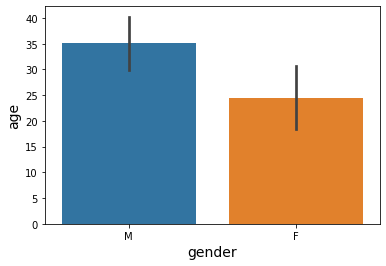

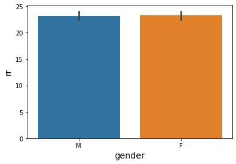

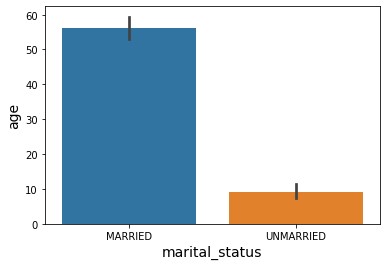

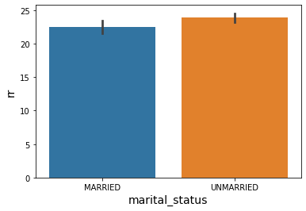

```python
numerical_features_set = ['age','rr']
categorical_features_set = ['gender','marital_status']

for c in categorical_features_set:
    for n in numerical_features_set:
        bar_plot(c,n)
```

## Model Approach 2: Without dummy variable coding

```python
import statsmodels.formula.api as smf
```

To print the name of all the models in any library

```python
#dir(smf)
```

```python
X_features = [x for x in filter_df if x not in ['body_weight','body_height',
                                           'creatinine','state_at_the_time_of_arrival',
                                           'total_amount_billed_to_the_patient','concession',
                                          'actual_receivable_amount','total_length_of_stay',
                                          'length_of_stay___icu','length_of_stay__ward']]
```

```python
new_df = filter_df.filter(X_features, axis =1)

new_df.info()
```

```
<class 'pandas.core.frame.DataFrame'>
Int64Index: 163 entries, 0 to 162
Data columns (total 17 columns):
 #   Column                     Non-Null Count  Dtype
---  ------                     --------------  -----
 0   age                        163 non-null    float64
 1   gender                     163 non-null    object
 2   marital_status             163 non-null    object
 3   key_complaints__code       163 non-null    object
 4   hr_pulse                   163 non-null    int64
 5   bp__high                   163 non-null    int64
 6   bp_low                     163 non-null    int64
 7   rr                         163 non-null    int64
 8   past_medical_history_code  163 non-null    object
 9   hb                         163 non-null    int64
 10  urea                       163 non-null    int64
 11  mode_of_arrival            163 non-null    object
 12  type_of_admsn              163 non-null    object
 13  total_cost_to_hospital     163 non-null    float64
 14  implant_used               163 non-null    object
 15  cost_of_implant            163 non-null    int64
 16  bmi                        163 non-null    float64
dtypes: float64(3), int64(7), object(7)
memory usage: 27.9+ KB
```

```python
from sklearn.model_selection import train_test_split

train_df, test_df = train_test_split( new_df, test_size = 0.2, random_state = 42)
```

Writing the formula with the required set of variables to be used in model building. Formula takes the form as Y~X.

```python
pass_formula = 'total_cost_to_hospital ~ \
            C(gender) + \
            C(marital_status) + \
            C(key_complaints__code) + \
            C(past_medical_history_code) + \
            C(mode_of_arrival) + \
            C(type_of_admsn)+ \
            C(implant_used) + \
            age + hr_pulse + bp__high + bp_low + \
            rr +hb + urea + cost_of_implant + bmi'
```

```python
regression_model = smf.ols(formula=pass_formula, data=train_df).fit()
regression_model.summary()
```

OLS Regression Results

| Dep. Variable: | total_cost_to_hospital | R-squared: | 0.567 |
| --- | --- | --- | --- |
| Model: | OLS | Adj. R-squared: | 0.463 |
| Method: | Least Squares | F-statistic: | 5.447 |
| Date: | Tue, 16 Mar 2021 | Prob (F-statistic): | 3.14e-10 |
| Time: | 20:07:40 | Log-Likelihood: | -1666.9 |
| No. Observations: | 130 | AIC: | 3386. |
| Df Residuals: | 104 | BIC: | 3460. |
| Df Model: | 25 |  |  |
| Covariance Type: | nonrobust |  |  |

|  | coef | std err | t | P>\|t\| | [0.025 | 0.975] |
| --- | --- | --- | --- | --- | --- | --- |
| Intercept | -2.238e+05 | 1.66e+05 | -1.345 | 0.182 | -5.54e+05 | 1.06e+05 |
| C(gender)[T.M] | 1.296e+04 | 2.16e+04 | 0.599 | 0.550 | -2.99e+04 | 5.58e+04 |
| C(marital_status)[T.UNMARRIED] | 6.486e+04 | 4.41e+04 | 1.470 | 0.145 | -2.27e+04 | 1.52e+05 |
| C(key_complaints__code)[T.CAD-DVD] | 1.433e+05 | 4.78e+04 | 2.999 | 0.003 | 4.85e+04 | 2.38e+05 |
| C(key_complaints__code)[T.CAD-TVD] | 1.238e+05 | 4.93e+04 | 2.508 | 0.014 | 2.59e+04 | 2.22e+05 |
| C(key_complaints__code)[T.OS-ASD] | 4.156e+04 | 4.4e+04 | 0.946 | 0.347 | -4.56e+04 | 1.29e+05 |
| C(key_complaints__code)[T.RHD] | -5.186e+04 | 5e+04 | -1.037 | 0.302 | -1.51e+05 | 4.73e+04 |
| C(key_complaints__code)[T.other- heart] | 4.871e+04 | 3.52e+04 | 1.384 | 0.169 | -2.11e+04 | 1.19e+05 |
| C(key_complaints__code)[T.other-tertalogy] | 5.896e+04 | 4.68e+04 | 1.259 | 0.211 | -3.39e+04 | 1.52e+05 |
| C(key_complaints__code)[T.others] | 7333.3118 | 4.48e+04 | 0.164 | 0.870 | -8.15e+04 | 9.61e+04 |
| C(past_medical_history_code)[T.diabetes] | 3.587e+04 | 4.13e+04 | 0.869 | 0.387 | -4.6e+04 | 1.18e+05 |
| C(past_medical_history_code)[T.hypertension] | -3.264e+04 | 3.3e+04 | -0.989 | 0.325 | -9.81e+04 | 3.28e+04 |
| C(past_medical_history_code)[T.other] | -3.735e+04 | 3.56e+04 | -1.048 | 0.297 | -1.08e+05 | 3.33e+04 |
| C(mode_of_arrival)[T.TRANSFERRED] | 1.257e+05 | 1.57e+05 | 0.799 | 0.426 | -1.86e+05 | 4.38e+05 |
| C(mode_of_arrival)[T.WALKED IN] | 1.14e+05 | 1.1e+05 | 1.032 | 0.304 | -1.05e+05 | 3.33e+05 |
| C(type_of_admsn)[T.EMERGENCY] | 1.394e+05 | 1.08e+05 | 1.287 | 0.201 | -7.55e+04 | 3.54e+05 |
| C(implant_used)[T.Y] | 1.316e+05 | 5.1e+04 | 2.580 | 0.011 | 3.05e+04 | 2.33e+05 |
| age | 2013.2379 | 973.038 | 2.069 | 0.041 | 83.668 | 3942.808 |
| hr_pulse | 937.4968 | 567.707 | 1.651 | 0.102 | -188.288 | 2063.281 |
| bp__high | 319.9341 | 741.341 | 0.432 | 0.667 | -1150.174 | 1790.042 |
| bp_low | -1010.1327 | 1001.742 | -1.008 | 0.316 | -2996.625 | 976.359 |
| rr | 3040.9463 | 2717.108 | 1.119 | 0.266 | -2347.181 | 8429.074 |
| hb | -636.4407 | 3220.833 | -0.198 | 0.844 | -7023.474 | 5750.592 |
| urea | 393.4563 | 653.097 | 0.602 | 0.548 | -901.660 | 1688.572 |
| cost_of_implant | 1.2582 | 0.978 | 1.286 | 0.201 | -0.681 | 3.198 |
| bmi | -91.9391 | 249.000 | -0.369 | 0.713 | -585.716 | 401.838 |

| Omnibus: | 82.903 | Durbin-Watson: | 1.987 |
| --- | --- | --- | --- |
| Prob(Omnibus): | 0.000 | Jarque-Bera (JB): | 626.472 |
| Skew: | 2.096 | Prob(JB): | 9.19e-137 |
| Kurtosis: | 12.904 | Cond. No. | 5.83e+05 |

Warnings:  
[1] Standard Errors assume that the covariance matrix of the errors is correctly specified.  
[2] The condition number is large, 5.83e+05. This might indicate that there are  
strong multicollinearity or other numerical problems.

## Find the significant variables

```python
def get_significant_vars (modelobject):
    var_p_vals_df = pd.DataFrame(modelobject.pvalues)
    var_p_vals_df['vars'] = var_p_vals_df.index
    var_p_vals_df.columns = ['pvals', 'vars']
    return list(var_p_vals_df[var_p_vals_df.pvals <= 0.05]['vars'])
```

```python
significant_vars = get_significant_vars(regression_model)
significant_vars
```

```
['C(key_complaints__code)[T.CAD-DVD]',
 'C(key_complaints__code)[T.CAD-TVD]',
 'C(implant_used)[T.Y]',
 'age']
```

## Model Evaluation

### 1. The prediction on train data.

Two ways to precit the outcome on the **train set**

> - Use **predict** function of the model object
> - Use **get_prediction** function of the model object

For the model with dummy variable coding explicetely done, we need to add the constant term to the test set. For the model with dummy variable coding carried out automatically, there is no need to add the constant term to the test set.

Here is the output with the model with no dummy variable coding

```python
predict_train_df = regression_model.predict((train_df))
predict_train_df.head()

predict_train_df = regression_model.get_prediction(train_df)
predict_train_df.predicted_mean[0:5]
```

```
84    135892.598214
2     333510.462816
94    183522.853799
45    216244.232684
42    268984.100132
dtype: float64
```

```
array([135892.59821424, 333510.4628162 , 183522.85379855, 216244.23268422,
       268984.10013156])
```

### 2. Model Evaluation - heteroscedasticity

```python
pred_val = regression_model.fittedvalues.copy()
true_val = train_df['total_cost_to_hospital'].values.copy()
residual = true_val - pred_val
```

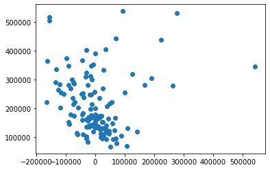

```python
plt.scatter(residual, pred_val)
```

### 3. Model Evaluation - Test for Normality

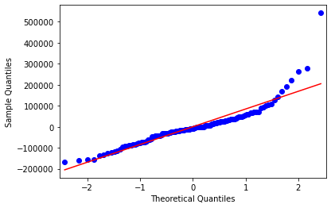

```python
import statsmodels.api as sm
normality_plot = sm.qqplot(residual,line = 'r')
```

### 4. The prediction on test data.

The prediction can be carried out by **defining functions** as well. Below is one such instance wherein a function is defined and is used for prediction

```python
def get_predictions ( test_actual, model, test_data ):
    y_pred_df = pd.DataFrame( { 'actual': test_actual,
                               'predicted': model.get_prediction((test_data)).predicted_mean})
    return y_pred_df
```

```python
predict_test_df = get_predictions( test_df.total_cost_to_hospital, regression_model, test_df)
predict_test_df.head()
```

|  | actual | predicted |
| --- | --- | --- |
| 135 | 73218.0 | 174963.121210 |
| 115 | 144134.0 | 264900.398145 |
| 131 | 109117.0 | 96844.282918 |
| 55 | 220519.0 | 255575.535725 |
| 95 | 140545.0 | 126739.185201 |